# Contract Exercised Options

### Other Office Characteristics

#### 12A: Past Office Volume (dollars)

Expectation: Contracting offices previously had more contract volume in dollars would have more experience managing cost and preventing cost-ceiling breaches, therefore larger past office volume would lower the likelihood of cost-ceiling breaches but no substantial relationships with likelihood of terminations or exercised options.

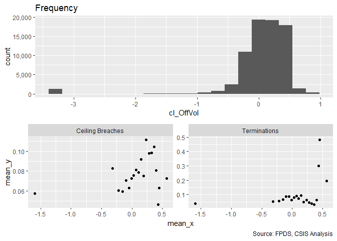

```r
summary_continuous_plot(serv_opt,"cl_OffVol")
```

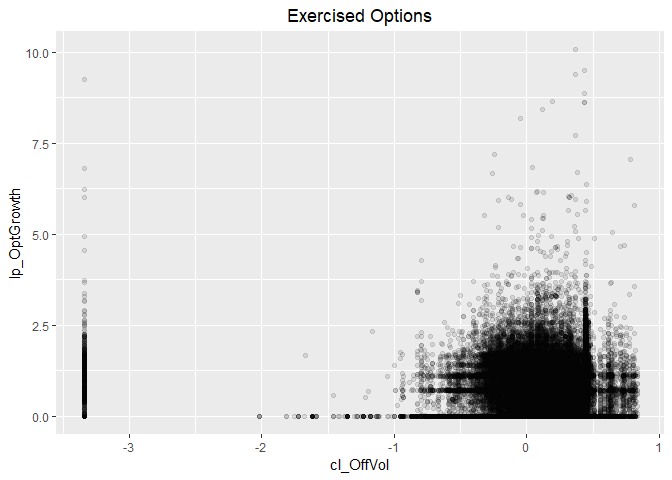

```r
#Scatter Plot
ggplot(serv_opt, aes(x=cl_OffVol, y=lp_OptGrowth)) + geom_point(alpha = 0.1) + ggtitle('Exercised Options') + theme(plot.title = element_text(hjust = 0.5))
```

```r
#Model
n_Opt_12A <- glm (data=serv_opt,
                 ln_OptGrowth ~ cl_OffVol)
display(n_Opt_12A)
```

```
## glm(formula = ln_OptGrowth ~ cl_OffVol, data = serv_opt)
##             coef.est coef.se
## (Intercept) 7.23     0.02
## cl_OffVol   0.25     0.04
## ---
##   n = 74162, k = 2
##   residual deviance = 2584452.2, null deviance = 2585789.3 (difference = 1337.1)
##   overdispersion parameter = 34.8
##   residual sd is sqrt(overdispersion) = 5.90
```

```r
p_Opt_12A <- glm(data=serv_opt,
                        lp_OptGrowth ~ cl_OffVol)

display(p_Opt_12A)
```

```
## glm(formula = lp_OptGrowth ~ cl_OffVol, data = serv_opt)
##             coef.est coef.se
## (Intercept) 0.65     0.00
## cl_OffVol   0.01     0.00
## ---
##   n = 74162, k = 2
##   residual deviance = 34940.3, null deviance = 34944.5 (difference = 4.2)
##   overdispersion parameter = 0.5
##   residual sd is sqrt(overdispersion) = 0.69
```

```r
#Plot residuals versus fitted
stargazer::stargazer(n_Opt_12A,

                       p_Opt_12A,
                       type="text",
                       digits=2)
```

```
##
## ==============================================
##                       Dependent variable:
##                   ----------------------------
##                    ln_OptGrowth  lp_OptGrowth
##                        (1)            (2)
## ----------------------------------------------
## cl_OffVol            0.25***        0.01***
##                       (0.04)        (0.005)
##
## Constant             7.23***        0.65***
##                       (0.02)        (0.003)
##
## ----------------------------------------------
## Observations          74,162        74,162
## Log Likelihood     -236,907.60    -77,324.78
## Akaike Inf. Crit.   473,819.20    154,653.60
## ==============================================
## Note:              *p<0.1; **p<0.05; ***p<0.01
```

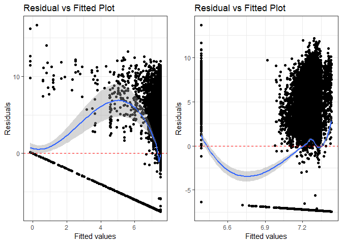

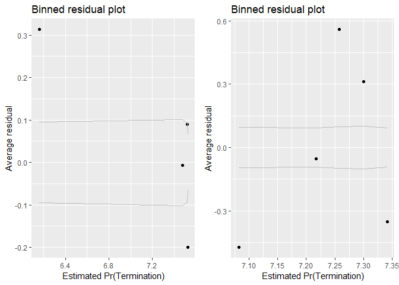

```r
summary_residual_compare(n_Opt_11A,n_Opt_12A, skip_vif = TRUE)
```

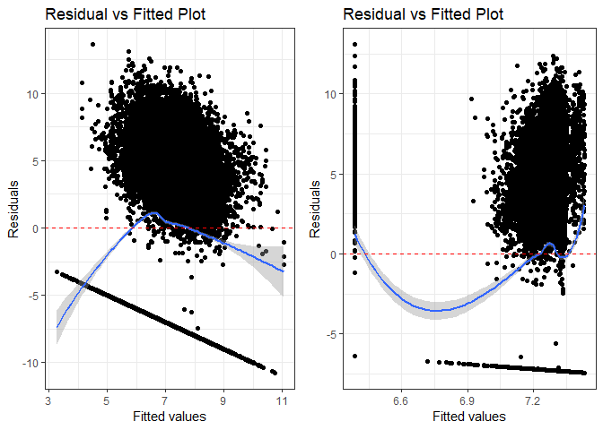

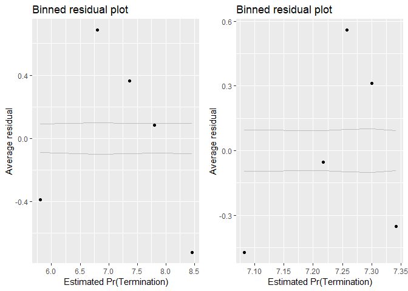

```r
summary_residual_compare(n_Opt_03D,n_Opt_12A, skip_vif = TRUE)
```

#### 12B: Detailed Industry Diveristy

Expectation: More diverse industries of contracts contracting offices handle, the higher complexity they deal with, which would increase the likelihood of having cost ceiling breaches and terminations, and decreasing the likelihood of having options exercised.

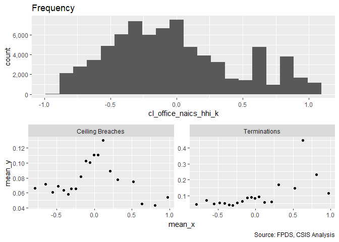

```r
summary_continuous_plot(serv_opt,"cl_office_naics_hhi_k")
```

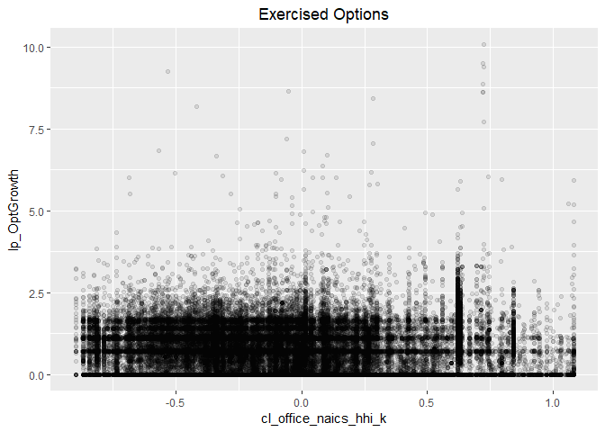

```r
#Scatter Plot
ggplot(serv_opt, aes(x=cl_office_naics_hhi_k, y=lp_OptGrowth)) + geom_point(alpha = 0.1) + ggtitle('Exercised Options') + theme(plot.title = element_text(hjust = 0.5))
```

```r
#Model
n_Opt_12B <- glm (data=serv_opt,
                 ln_OptGrowth ~ cl_office_naics_hhi_k)
display(n_Opt_12B)
```

```
## glm(formula = ln_OptGrowth ~ cl_office_naics_hhi_k, data = serv_opt)
##                       coef.est coef.se
## (Intercept)            7.19     0.02
## cl_office_naics_hhi_k -1.78     0.05
## ---
##   n = 74162, k = 2
##   residual deviance = 2532468.1, null deviance = 2585789.3 (difference = 53321.2)
##   overdispersion parameter = 34.1
##   residual sd is sqrt(overdispersion) = 5.84
```

```r
p_Opt_12B <- glm(data=serv_opt,
                        lp_OptGrowth ~ cl_office_naics_hhi_k)

display(p_Opt_12B)
```

```
## glm(formula = lp_OptGrowth ~ cl_office_naics_hhi_k, data = serv_opt)
##                       coef.est coef.se
## (Intercept)            0.64     0.00
## cl_office_naics_hhi_k -0.09     0.01
## ---
##   n = 74162, k = 2
##   residual deviance = 34815.7, null deviance = 34944.5 (difference = 128.9)
##   overdispersion parameter = 0.5
##   residual sd is sqrt(overdispersion) = 0.69
```

```r
#Plot residuals versus fitted
stargazer::stargazer(n_Opt_12B,

                       p_Opt_12B,
                       type="text",
                       digits=2)
```

```
##
## ==================================================
##                           Dependent variable:
##                       ----------------------------
##                        ln_OptGrowth  lp_OptGrowth
##                            (1)            (2)
## --------------------------------------------------
## cl_office_naics_hhi_k    -1.78***      -0.09***
##                           (0.05)        (0.01)
##
## Constant                 7.19***        0.64***
##                           (0.02)        (0.003)
##
## --------------------------------------------------
## Observations              74,162        74,162
## Log Likelihood         -236,154.10    -77,192.24
## Akaike Inf. Crit.       472,312.20    154,388.50
## ==================================================
## Note:                  *p<0.1; **p<0.05; ***p<0.01
```

```r
# summary_residual_compare(n_Opt_11A,n_Opt_12B, skip_vif = TRUE)
# summary_residual_compare(n_Opt_03D,n_Opt_12B, skip_vif = TRUE)
```

When using hhi calculated based on contracting office obligation: considering hhi alone, expectation for Temrination was not met. When using hhi calculated based on contracting office number of contarcts: considering hhi alone, all expectation were met.

#### 12C: Cumulative Model

```r
#Frequency Plot for unlogged ceiling


#Model
n_Opt_12C <- glm (data=serv_opt,
                 ln_OptGrowth ~  cl_US6_avg_sal_lag1Const +
                   cl_CFTE+ c_pPBSC+c_pOffPSC+
                 c_pairHist+cl_pairCA +
                   cl_Ceil + capped_cl_Days+
                   Comp1or5+
                   Veh+
                   PricingUCA+
                   Crisis+
                   cl_def6_HHI_lag1+cl_def6_ratio_lag1+
                   cl_def3_HHI_lag1+cl_def3_ratio_lag1+
                   c_pMarket+
                   cl_OffVol+cl_office_naics_hhi_k )
glmer_examine(n_Opt_12C)
```

```
##                              GVIF Df GVIF^(1/(2*Df))
## cl_US6_avg_sal_lag1Const 2.149929  1        1.466263
## cl_CFTE                  1.589205  1        1.260637
## c_pPBSC                  1.381322  1        1.175297
## c_pOffPSC                2.152681  1        1.467202
## c_pairHist               1.606883  1        1.267629
## cl_pairCA                3.846476  1        1.961243
## cl_Ceil                  1.519653  1        1.232742
## capped_cl_Days           1.197813  1        1.094447
## Comp1or5                 1.690071  3        1.091400
## Veh                      4.179752  4        1.195759
## PricingUCA               1.414772  6        1.029336
## Crisis                   1.778660  3        1.100733
## cl_def6_HHI_lag1         1.544219  1        1.242666
## cl_def6_ratio_lag1       1.558364  1        1.248345
## cl_def3_HHI_lag1         1.960960  1        1.400343
## cl_def3_ratio_lag1       2.102066  1        1.449850
## c_pMarket                2.009293  1        1.417495
## cl_OffVol                1.235965  1        1.111740
## cl_office_naics_hhi_k    1.707522  1        1.306722
```

```r
p_Opt_12C <- glm(data=serv_opt,
                        lp_OptGrowth ~  cl_US6_avg_sal_lag1Const +
                   cl_CFTE+ c_pPBSC+c_pOffPSC+
                 c_pairHist+cl_pairCA+
                 cl_Ceil + capped_cl_Days+
                 Comp1or5+
                   Veh+
                   PricingUCA+
                   Crisis+
                 cl_def6_HHI_lag1+cl_def6_ratio_lag1+
                 cl_def3_HHI_lag1+cl_def3_ratio_lag1+
                 c_pMarket+
                   cl_OffVol+cl_office_naics_hhi_k)

glmer_examine(p_Opt_12C)
```

```
##                              GVIF Df GVIF^(1/(2*Df))
## cl_US6_avg_sal_lag1Const 2.149929  1        1.466263
## cl_CFTE                  1.589205  1        1.260637
## c_pPBSC                  1.381322  1        1.175297
## c_pOffPSC                2.152681  1        1.467202
## c_pairHist               1.606883  1        1.267629
## cl_pairCA                3.846476  1        1.961243
## cl_Ceil                  1.519653  1        1.232742
## capped_cl_Days           1.197813  1        1.094447
## Comp1or5                 1.690071  3        1.091400
## Veh                      4.179752  4        1.195759
## PricingUCA               1.414772  6        1.029336
## Crisis                   1.778660  3        1.100733
## cl_def6_HHI_lag1         1.544219  1        1.242666
## cl_def6_ratio_lag1       1.558364  1        1.248345
## cl_def3_HHI_lag1         1.960960  1        1.400343
## cl_def3_ratio_lag1       2.102066  1        1.449850
## c_pMarket                2.009293  1        1.417495
## cl_OffVol                1.235965  1        1.111740
## cl_office_naics_hhi_k    1.707522  1        1.306722
```

```r
#Plot residuals versus fitted
stargazer::stargazer(n_Opt_11B,n_Opt_12A,n_Opt_12C,

                     p_Opt_11B,p_Opt_12A,p_Opt_12C,
                       type="text",
                       digits=2)
```

```
##
## ===================================================================================================
##                                                        Dependent variable:
##                                --------------------------------------------------------------------
##                                           ln_OptGrowth                       lp_OptGrowth
##                                    (1)         (2)         (3)        (4)        (5)        (6)
## ---------------------------------------------------------------------------------------------------
## cl_US6_avg_sal_lag1Const         0.23***                 0.32***    0.02***               0.03***
##                                  (0.05)                  (0.05)      (0.01)                (0.01)
##
## cl_CFTE                         -0.72***                -0.68***    -0.11***              -0.11***
##                                  (0.05)                  (0.05)      (0.01)                (0.01)
##
## c_pPBSC                           -0.01                   -0.03     -0.03***              -0.03***
##                                  (0.05)                  (0.05)      (0.01)                (0.01)
##
## c_pOffPSC                        0.75***                 1.05***    0.18***               0.21***
##                                  (0.07)                  (0.07)      (0.01)                (0.01)
##
## c_pairHist                       0.16***                 0.09**      -0.01                 -0.01*
##                                  (0.05)                  (0.05)      (0.01)                (0.01)
##
## cl_pairCA                        0.60***                 0.80***    0.14***               0.15***
##                                  (0.07)                  (0.07)      (0.01)                (0.01)
##
## cl_Ceil                          3.36***                 3.35***    0.14***               0.14***
##                                  (0.05)                  (0.05)      (0.01)                (0.01)
##
## capped_cl_Days                   1.27***                 1.22***    -0.0004                -0.002
##                                  (0.06)                  (0.06)      (0.01)                (0.01)
##
## Comp1or51 offer                   0.08                    0.004     0.06***               0.06***
##                                  (0.06)                  (0.06)      (0.01)                (0.01)
##
## Comp1or52-4 offers                -0.04                   -0.05     0.03***               0.03***
##                                  (0.06)                  (0.06)      (0.01)                (0.01)
##
## Comp1or55+ offers                0.32***                 0.35***    0.10***               0.10***
##                                  (0.06)                  (0.06)      (0.01)                (0.01)
##
```

[output cut: 54 more lines]

```
## cl_OffVol                                    0.25***      0.07*                0.01***    -0.01**
##                                              (0.04)      (0.04)                (0.005)    (0.005)
##
## cl_office_naics_hhi_k                                   -0.94***                          -0.08***
##                                                          (0.05)                            (0.01)
##
## Constant                         6.17***     7.23***     6.14***    0.66***    0.65***    0.66***
##                                  (0.06)      (0.02)      (0.06)      (0.01)    (0.003)     (0.01)
##
## ---------------------------------------------------------------------------------------------------
## Observations                     74,162      74,162      74,162      74,162     74,162     74,162
## Log Likelihood                 -228,855.20 -236,907.60 -228,694.20 -72,517.08 -77,324.78 -72,448.33
## Akaike Inf. Crit.              457,770.40  473,819.20  457,452.50  145,094.20 154,653.60 144,960.70
## ===================================================================================================
## Note:                                                                   *p<0.1; **p<0.05; ***p<0.01
```

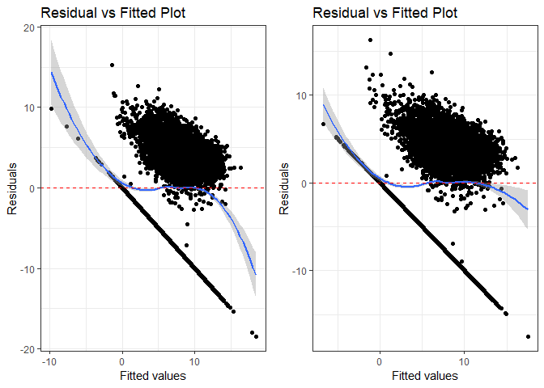

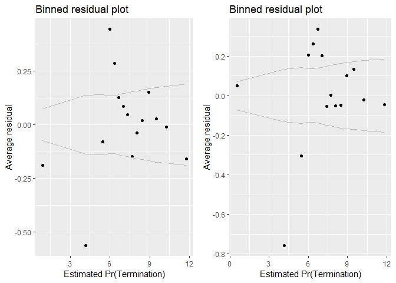

```
## [[1]]
##        model deviance null.deviance difference
## 1 model1_old  2101902       2585789   483887.7
## 2 model1_new  2070969       2585789   514820.6
##
## [[2]]
##                              GVIF Df GVIF^(1/(2*Df))
## cl_US6_avg_sal_lag1Const 2.149929  1        1.466263
## cl_CFTE                  1.589205  1        1.260637
## c_pPBSC                  1.381322  1        1.175297
## c_pOffPSC                2.152681  1        1.467202
## c_pairHist               1.606883  1        1.267629
## cl_pairCA                3.846476  1        1.961243
## cl_Ceil                  1.519653  1        1.232742
## capped_cl_Days           1.197813  1        1.094447
## Comp1or5                 1.690071  3        1.091400
## Veh                      4.179752  4        1.195759
## PricingUCA               1.414772  6        1.029336
## Crisis                   1.778660  3        1.100733
## cl_def6_HHI_lag1         1.544219  1        1.242666
## cl_def6_ratio_lag1       1.558364  1        1.248345
## cl_def3_HHI_lag1         1.960960  1        1.400343
## cl_def3_ratio_lag1       2.102066  1        1.449850
## c_pMarket                2.009293  1        1.417495
## cl_OffVol                1.235965  1        1.111740
## cl_office_naics_hhi_k    1.707522  1        1.306722
```

```r
summary_residual_compare(n_Opt_10D,n_Opt_12C)
```

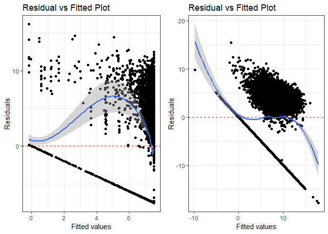

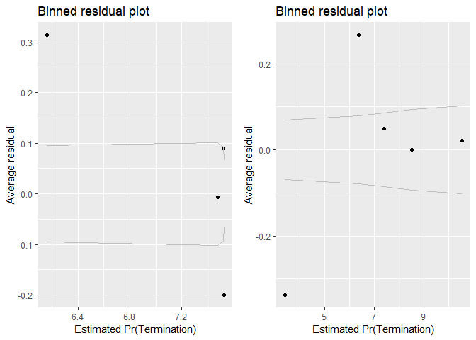

```
## [[1]]
##        model deviance null.deviance difference
## 1 model1_old  2495828       2585789   89961.76
## 2 model1_new  2070969       2585789  514820.58
##
## [[2]]
##                              GVIF Df GVIF^(1/(2*Df))
## cl_US6_avg_sal_lag1Const 2.149929  1        1.466263
## cl_CFTE                  1.589205  1        1.260637
## c_pPBSC                  1.381322  1        1.175297
## c_pOffPSC                2.152681  1        1.467202
## c_pairHist               1.606883  1        1.267629
## cl_pairCA                3.846476  1        1.961243
## cl_Ceil                  1.519653  1        1.232742
## capped_cl_Days           1.197813  1        1.094447
## Comp1or5                 1.690071  3        1.091400
## Veh                      4.179752  4        1.195759
## PricingUCA               1.414772  6        1.029336
## Crisis                   1.778660  3        1.100733
## cl_def6_HHI_lag1         1.544219  1        1.242666
## cl_def6_ratio_lag1       1.558364  1        1.248345
## cl_def3_HHI_lag1         1.960960  1        1.400343
## cl_def3_ratio_lag1       2.102066  1        1.449850
## c_pMarket                2.009293  1        1.417495
## cl_OffVol                1.235965  1        1.111740
## cl_office_naics_hhi_k    1.707522  1        1.306722
```

```r
summary_residual_compare(n_Opt_11A,n_Opt_12C)
```